# Part II - Impact of Characteristics of trip data on Duration of trip

## Dataset Overview

> This dataset includes records of individual rides made in a bike-sharing system covering the greater San Francisco Bay area in Feb-2019.

> The features of the dataset after the preliminary wrangling :

> ```
>     - duration_sec.
>     - start_time.
>     - end_time.
>     - user_type : Subscriber & Customer.
>     - member_birth_year.
>     - member_gender : Male, Female & Other
> ```

> Besides, I created new columns from given columns:

> ```
>     - age : derived from the member_birth_year
>     - start_hour: to store hour number from start_time.
>     - end_hour: to store hour number from end_time.
>     - start_weekday: to store week day number from start_time.
> ```

## How does the duration of trips vary ?

The main thing I want to explore is how the trip duration distributed. From part I, we saw that was a long tail in the distribution, so we choose the plot of duration_sec on a logartithmic scale.

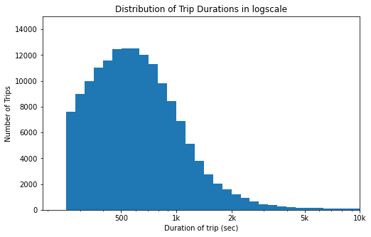

Most of trips took less than 2000 seconds (around 30min).

## How does the average trip duration vary between customers and subscribers during weekdays ?

The main thing I want to explore is how the average trip duration vary between customers and subscribers during weekdays.

[figure not shown]

We can state that subscribers take shorter trips compared to customers all week long & use the bike system in a efficient way (being near the average from Monday-Friday) .

Also both user types have increase their trip duration over weekends.

## How does the trip duration distribution vary between customers and subscribers accross gender?

The main thing I want to explore in this part of the analysis is how does the trip duration distribution vary between customers and subscribers accross gender.

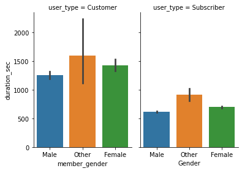

This investigation shows clearly that customers have a higher mean trip duration across all genders.